# Launching a Rocket

In the previous exercises, we showed how numerical integration can be implemented with a Simple Euler or Improved Euler method. More sophisticated algorithms achieve higher accuracy by using more terms in the Taylor series approximation while taking the next step. (For example, one such easily coded algorithm is the fourth-order Runge-Kutta). This exercise introduces the higher-accuracy, ordinary differential equation solver included in Python, `solve_ivp()`. You will apply it to the problem of a rocket launching in a gravitational field. Specifically, you will model the launch of the Space Shuttle, a two-stage rocket, with the simplifying assumption that the trajectory is vertical, and the acceleration due to gravity remains constant.

While this problem can be solved analytically, it is a good illustration of how sets of first-order differential equations can be rewritten to be solved with a computer.

**Exercises 9** and **10** ask students to compare the solutions from `solve_ivp()` to those generated using an Improved Euler method similar to that used in Numerical Integration Applied to Projectile Motion and Projectile Motion with Drag. These exercises may be omitted to save time without affecting the rest of the unit.

## Objectives

In this unit you will

- learn how to use `solve_ivp()` to solve ordinary differential equations (PRO);
- analytically and computationally solve the motion of a rocket in an external gravitational field (PHY);
- model a two-stage rocket launch (PHY).

```python
#%matplotlib inline
import numpy as np
import matplotlib.pyplot as plt

plt.rcParams["figure.figsize"] = (12,8) # make figures big for easier viewing
                                        #    (width, height in inches)
# To revert to the small default size uncomment the following line
# plt.rcParams["figure.figsize"] = plt.rcParamsDefault["figure.figsize"]
```

## Motion of Rocket without Gravity

In order to familiarize yourself with numerically solving differential equations, you will start with the simplest case: a rocket experiencing no external forces.

In the next section, you will use the Python numerical solver, `solve_ivp()`, to find the velocity as a function of mass. Before that, though, you will set up the problem and graph the analytical solution.

#### Exercise 1

In the code block below, please define variables for the initial mass of the rocket (`mass_0`), final mass of the rocket that remains after the payload is exhausted (`mass_final`), the amount of time during which the rocket is expelling mass (`burn_time`), exhaust speed (`vel_ex`), and the initial velocity of the rocket (`vel_0`). Use the data on the Space Shuttle from Problem 3.7 of *Classical Mechanics*.

```python
# < Exercise 1, Defining the variables >

### FILL IN the information below:

mass_0 = 0 # [kg]; Initial mass of the Space Shuttle
mass_final = 0 # [kg]; Final mass after fuel in the Space Shuttle Solid Rocket
               #    Booster has been expended
mass_propel = mass_0 - mass_final # [kg]; Mass of propellant contained in
                                  #    Space Shuttle Solid Rocket Booster
burn_time = 0 # [s]; Amount of time before propellant is exhausted from the
              #    first stage boosters.
vel_ex = 0 # [m/s]; Exhaust velocity
vel_0 = 0 # [m/s]; Initial velocity

#/ < Exercise 1, Defining the variables, Instructor solution >
mass_0 = 2e6 # [kg]; Initial mass of the Space Shuttle
mass_final = 1e6 # [kg]; Final mass after fuel in the Space Shuttle Solid
                 #    Rocket Booster has been expended
mass_propel = mass_0 - mass_final # [kg]; mass of propellant contained in
                                  #    Space Shuttle Solid Rocket Booster
burn_time = 120 # [s]; Amount of time before propellant is exhausted.
vel_ex = 3000 # [m/s]; Exhaust velocity
vel_0 = 0 # [m/s]; Initial velocity
#/
```

#### Exercise 2

Using the analytical solution given in Equation 3.8 of *Classical Mechanics*, graph the velocity as a function of mass. For the independent variable, `mass`, define an array of at least 50 elements that runs from the initial mass to the final mass.

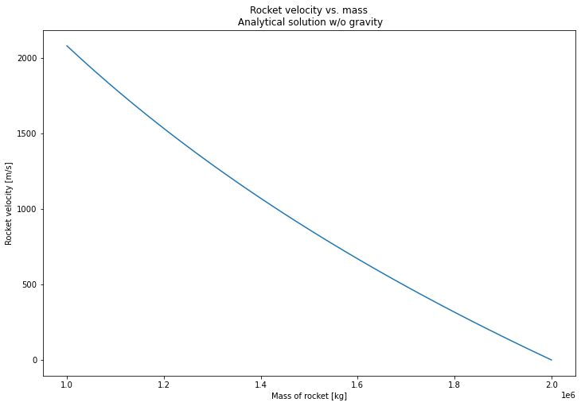

```python
# < Exercise 2, Plots >

# Array of rocket masses
mass = 0 ### FIX

# Analytically calculated velocities
vel = mass ### FIX

### INCLUDE code for plotting velocity versus mass

#/ < Exercise 2, Plots, Instructor solution >
# ---------------------------------------------
# Array of rocket masses
mass = np.linspace(mass_0, mass_final, 50)
# Analytically calculated velocities
vel = vel_ex*np.log(mass_0/mass) - vel_0

fig, ax = plt.subplots()
ax.plot(mass, vel)
ax.set_title("Rocket velocity vs. mass\n Analytical solution w/o gravity")
ax.set_ylabel("Rocket velocity [m/s]")
ax.set_xlabel("Mass of rocket [kg]")
plt.show()
# ---------------------------------------------
#/
```

#### Exercise 3

Sometimes it is more natural to think in terms of velocity as a function of time, rather than mass of the rocket. This conversion can be done *if* the change in mass as a function of time is known. Assume here that mass is expelled at a constant rate, $\dot m = -k$, and that the entire process takes place over the "burn time" defined in **Exercise 1**. Therefore,

$ m(t) = m_0 - k t $.

In the cell below, calculate $k$ (`burn_rate`). Then rearrange the above equation for $m(t)$ to find $t(m)$, and use that relation to plot rocket velocity as a function of time.

```
Burn rate, k = 8333.33 kg/s
```

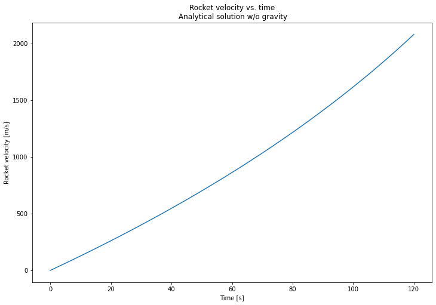

```python
# < Exercise 3, Convert mass to time >

### FIX the two definitions below
burn_rate = 0 # [kg/s]; Rate at which mass is expelled
time_arr = mass # [s]; Array of times

### INCLUDE code for plotting velocity versus time

#/ < Exercise 3, Convert mass to time, Instructor solution >
# ---------------------------------------------
burn_rate = (mass_0 - mass_final)/burn_time  # [kg/s]; Rate at which mass is
                                             #    expelled
print("Burn rate, k = {:3.2f} kg/s".format(burn_rate))
time_arr = (mass_0 - mass)/burn_rate

fig, ax = plt.subplots()
ax.plot(time_arr, vel)
ax.set_title("Rocket velocity vs. time\n Analytical solution w/o gravity")
ax.set_ylabel("Rocket velocity [m/s]")
ax.set_xlabel("Time [s]")
plt.show()
# ---------------------------------------------
#/
```

#### Exercise 4

Perhaps just as interesting as velocity as a function of time is the position as a function of time. To find this, analytically integrate Equation 3.8 from *Classical Mechanics* for velocity to find the position as a function of time. Use your equation for $m(t)$ assuming a constant burn rate over 2 minutes. Then plot position versus time. You should find that the height already exceeds 100 km after 2 minutes.

*Height after 2 minutes =*

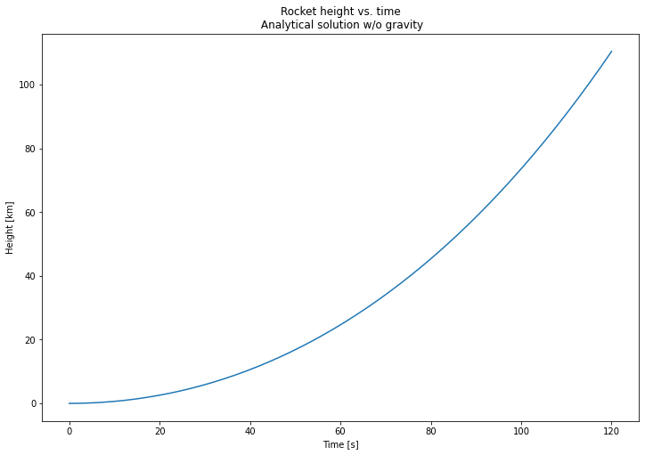

```
Height after 2 minutes: 110.47 km
```

```python
# < Exercise 4, Position vs. time >

### INCLUDE code to plot the position versus time.


#/ < Exercise 4, Position vs. time, Instructor solution >
# ---------------------------------------------
# For derivation, see instructor guide for *Classical Mechanics*,
#    Problem 3.13 without gravity
pos = (vel_ex*((time_arr - mass_0/burn_rate)*
               np.log(mass_0/(mass_0 - burn_rate*time_arr)) + time_arr))

fig, ax = plt.subplots()
ax.plot(time_arr, pos/1000)
ax.set_title("Rocket height vs. time\n Analytical solution w/o gravity")
ax.set_ylabel("Height [km]")
ax.set_xlabel("Time [s]")
plt.show()

print("Height after 2 minutes: {:3.2f} km".format(pos[-1]/1000))
# ---------------------------------------------
#/
```

## Introducing solve_ivp for a Rocket

The differential equation solver, solve_ivp (short for "solve initial value problem"), is part of the SciPy package, which must be loaded at run time using the command `import`.

Previously, you solved differential equations by defining an "r-array" that consisted of the values of each variable to be integrated over (e.g., generalized positions and velocities) at a particular time. You then used a function to return the derivatives for each of those variables, determined the value of those variables at the subsequent time step, and appended the r-array for that subsequent time step to your solution. If you had *n* variables and *N* time steps, the solution would be a two-dimensional *n*x*N* array.

With `solve_ivp()`, though, the solver determines the array of time points (using a user-defined time span as one of its arguments) and outputs an array of r-arrays (really, a two-dimensional *n*x*N* array), eliminating the for loop we used in the previous labs. Thus you will no longer be building up the solution by repeatedly appending to an array; instead, the *solve_ivp* solver will output the entire solution as a two-dimensional array, along with the array of times over which it was evaluated. The output of `solve_ivp()` is in the form of a programming "object": if the output is `r_soln`, the times will be accessible as `r_soln.t` and the two-dimensional array as `r_soln.y`.

The exercises below will walk you through how to find and interpret the numerical solution to the rocket problem generated by `solve_ivp()`.

*For a more comprehensive and general introduction to `solve_ivp()`, refer to the Appendix 1: Using solve_ivp for Numerical Integration.*

```python
# Import the differential equation integrator
#    To reduce demand on memory, we import only the subset of the SciPy
#    package that contains solve_ivp
from scipy.integrate import solve_ivp
```

### Defining the `deriv()` function

To use the `solve_ivp()` solver, the user must provide the system of first-order ordinary differential equations in the form of a function (what will typically be called `deriv()`) that returns the derivative for each variable. The `deriv()` function takes as its parameters a single time, `t_now`, an array of the variables, `r_arr`, defining the state of the system at `t_now`, and any other constants of the system necessary for solving the derivatives. It then returns an array containing the derivatives of each of those variables in the same order as they were passed to the function.

#### Exercise 5

In this case, the variables to be integrated are *mass*, *position*, and *velocity.* Modify the code below to create a function `deriv()` that will return the derivatives of each of these variables at a particular time, `t_now`. The variables `mass`, `position`, and `velocity` are all passed to the function as elements of an r-array, `r_now`, and the return of the function is an array of the derivatives of those variables in the same order.

In the base code below, the `deriv()` function also takes *burn_rate* and *vel_ex* as optional parameters. This will allow you to compute solutions for situations with different values of *burn_rate* and *vel_ex*. Note that if *burn_rate* and *vel_ex* are not passed to the `deriv()` function they will default to zero (and the rocket will not move).

```python
# < Exercise 5, Computational solution for rocket, the deriv function >

# Deriv function for use by solve_ivp

# As you did when writing your own integrator, create a function to evaluate
#    the derivatives
def deriv(t_now, r_now, burn_rate = 0, vel_ex = 0):
    """ Supplies the derivatives of mass, position, and velocity to be used
    by the differential equation integrator, solve_ivp. The optional
    parameters burn_rate, and vel_ex are set to zero by default. """

    # Unpack the r-array for the mass, position, and velocity
    mass, pos, vel = r_now # Notice that this syntax is equivalent to
                           #    separately defining
                           #    mass = r_now[0],
                           #    pos = r_now[1]
                           #    vel = r_now[2] but is shorter and cleaner

    dmass_dt = 0  ### REPLACE 0 with the appropriate expression
    dpos_dt = 0  ### REPLACE 0 with the appropriate expression
                 #    Hint:  This is probably simpler than you think.
    dvel_dt = 0  ### REPLACE 0 with the appropriate expression

#/ < Exercise 5, Computational solution for rocket, the deriv() function,
#    Instructor solution >
# ---------------------------------------------
    dmass_dt = -burn_rate
    dpos_dt = vel
    dvel_dt = -1*(vel_ex/mass)*dmass_dt

# ---------------------------------------------
#/
    return np.array([dmass_dt, dpos_dt, dvel_dt])
```

### Finding the solution with `solve_ivp()`

Now that the derivatives have been defined, the user must define the initial conditions (the eponymous initial values in `solve_ivp()`). This is done by defining an array of the initial states of the variables to be integrated, in the same order as assumed for the *r* array in `deriv()`.

Next, the integration time must be defined. Unlike other solvers, `solve_ivp()` is special in that it can determine the time steps over which to find the solution to minimize the computational time (this is an example of an *adaptive* solver). Remarkably, these time steps typically have uneven spacing. While it is possible to ask `solve_ivp()` to use a particular array of user-defined time steps, by default the user only passes the range of times. Generally, the user will define a two-element list stating the minimum and maximum time. *(Alternatively, the range can be passed in the form of a tuple rather than a list. Tuples are like lists except that they are defined with parentheses rather than square brackets and are immutable, i.e., unchangeable. Using tuples rather than lists is slightly more memory efficient, but feel free to continue to use lists for the sake of simplicity.)*

Finally, the name of the function containing the derivatives, the time span for the solution, and the initial conditions are all passed to `solve_ivp()` along with any optional parameters for the `deriv()` function.

#### Exercise 6

Fill in the requested information in the code cell below to find the computational solution. Use the same parameters as you did in **Exercise 1** and complete the integration for the entire burn time.

```python
# < Exercise 6, Computational solution for rocket, calling solve_ivp >

# Set the initial conditions
r_init = np.array([0, 0, 0]) ### FIX # initial mass, position, and velocity
                                     #    These must be in the same order as
                                     #    accessed in deriv()

#/ < Exercise 6, Computational solution for rocket, Instructor solution, ICs >
r_init = np.array([mass_0, 0, 0])
#/

# Define the range of times over which a solution is desired
t_span = [0.0, 0.0] ### FIX # List of minimum and maximum times

#/ < Exercise 6, Computational solution for rocket, Instructor solution,
#    time span >
t_span = [0.0, burn_time]
#/

# Call solve_ivp
#    solve_ivp takes the name of the function of derivatives (deriv), the time
#    span for the solutions (t_span), an array of initial conditions (r_init),
#    and optional parameters to be passed to the deriv function
r_soln = solve_ivp(deriv, t_span, r_init, args = (burn_rate, vel_ex))
```

### Accessing the solution from *solve_ivp*

The return from `solve_ivp()` is a programming object that contains lots of information. Soon you will see an example of how to access the data in it. Initially, though, a complete description of the contents of `r_soln` may be seen by using the `help()` function, e.g.,

```
help(r_soln)
```

The `help()` function in Python returns information about variables, functions, classes and so on, as illustrated in the cells below. It is a very useful debugging tool and a quick way to learn about functions and classes from Python libraries.

```python
# Print out information about the function, solve_ivp()
help(solve_ivp)

# Once you have run this cell, you may wish to comment out the above commands
#    to avoid cluttering your output
```

```
Help on function solve_ivp in module scipy.integrate._ivp.ivp:

solve_ivp(fun, t_span, y0, method='RK45', t_eval=None, dense_output=False, events=None, vectorized=False, args=None, **options)
    Solve an initial value problem for a system of ODEs.

    This function numerically integrates a system of ordinary differential
    equations given an initial value::

        dy / dt = f(t, y)
        y(t0) = y0

    Here t is a 1-D independent variable (time), y(t) is an
    N-D vector-valued function (state), and an N-D
    vector-valued function f(t, y) determines the differential equations.
    The goal is to find y(t) approximately satisfying the differential
    equations, given an initial value y(t0)=y0.

    Some of the solvers support integration in the complex domain, but note
    that for stiff ODE solvers, the right-hand side must be
    complex-differentiable (satisfy Cauchy-Riemann equations [11]_).
    To solve a problem in the complex domain, pass y0 with a complex data type.
    Another option always available is to rewrite your problem for real and
    imaginary parts separately.

    Parameters
    ----------
    fun : callable
        Right-hand side of the system. The calling signature is ``fun(t, y)``.
        Here `t` is a scalar, and there are two options for the ndarray `y`:
        It can either have shape (n,); then `fun` must return array_like with
        shape (n,). Alternatively, it can have shape (n, k); then `fun`
        must return an array_like with shape (n, k), i.e., each column
        corresponds to a single column in `y`. The choice between the two
        options is determined by `vectorized` argument (see below). The
        vectorized implementation allows a faster approximation of the Jacobian
        by finite differences (required for stiff solvers).
    t_span : 2-tuple of floats
        Interval of integration (t0, tf). The solver starts with t=t0 and
        integrates until it reaches t=tf.
    y0 : array_like, shape (n,)
```

[output cut: 291 more lines]

```
    argument.

    >>> sol = solve_ivp(lotkavolterra, [0, 15], [10, 5], args=(1.5, 1, 3, 1),
    ...                 dense_output=True)

    Compute a dense solution and plot it.

    >>> t = np.linspace(0, 15, 300)
    >>> z = sol.sol(t)
    >>> import matplotlib.pyplot as plt
    >>> plt.plot(t, z.T)
    >>> plt.xlabel('t')
    >>> plt.legend(['x', 'y'], shadow=True)
    >>> plt.title('Lotka-Volterra System')
    >>> plt.show()
```

```python
# Print out information about the variable r_soln returned by solve_ivp()
help(r_soln)

# Once you have run this cell, you may wish to comment out the above commands
#    to avoid cluttering your output
```

```
Help on OdeResult in module scipy.integrate._ivp.ivp object:

class OdeResult(scipy.optimize.optimize.OptimizeResult)
 |  Represents the optimization result.
 |  Attributes
 |  ----------
 |  x : ndarray
 |      The solution of the optimization.
 |  success : bool
 |      Whether or not the optimizer exited successfully.
 |  status : int
 |      Termination status of the optimizer. Its value depends on the
 |      underlying solver. Refer to `message` for details.
 |  message : str
 |      Description of the cause of the termination.
 |  fun, jac, hess: ndarray
 |      Values of objective function, its Jacobian and its Hessian (if
 |      available). The Hessians may be approximations, see the documentation
 |      of the function in question.
 |  hess_inv : object
 |      Inverse of the objective function's Hessian; may be an approximation.
 |      Not available for all solvers. The type of this attribute may be
 |      either np.ndarray or scipy.sparse.linalg.LinearOperator.
 |  nfev, njev, nhev : int
 |      Number of evaluations of the objective functions and of its
 |      Jacobian and Hessian.
 |  nit : int
 |      Number of iterations performed by the optimizer.
 |  maxcv : float
 |      The maximum constraint violation.
 |  Notes
 |  -----
 |  There may be additional attributes not listed above depending of the
 |  specific solver. Since this class is essentially a subclass of dict
 |  with attribute accessors, one can see which attributes are available
 |  using the `keys()` method.
 |  Method resolution order:
 |      OdeResult
 |      scipy.optimize.optimize.OptimizeResult
 |      builtins.dict
```

[output cut: 72 more lines]

```
 |      If E is present and lacks a .keys() method, then does:  for k, v in E: D[k] = v
 |      In either case, this is followed by: for k in F:  D[k] = F[k]
 |  values(...)
 |      D.values() -> an object providing a view on D's values
 |  ----------------------------------------------------------------------
 |  Class methods inherited from builtins.dict:
 |  fromkeys(iterable, value=None, /) from builtins.type
 |      Create a new dictionary with keys from iterable and values set to value.
 |  ----------------------------------------------------------------------
 |  Static methods inherited from builtins.dict:
 |  __new__(*args, **kwargs) from builtins.type
 |      Create and return a new object.  See help(type) for accurate signature.
 |  ----------------------------------------------------------------------
 |  Data and other attributes inherited from builtins.dict:
 |  __hash__ = None
```

The cell below shows you the information contained in this particular instance of `r_soln`, including how to access specific quantities from it. Most important is the success of the integration (accessible as `r_soln.success`), the time-steps (accessible as `r_soln.t`), and the two-dimensional array of solutions (accessible through `r_soln.y`). The first column of `r_soln.y` (accessible as `r_soln.y[0]` or `r_soln.y[0,:]`) gives the values for the first variable listed in the `r_init` and in the variable `r_now` used by `deriv()`. The second column gives the values for the second variable and so on.

*If you look closely at the values for the time step, you will notice that they initially increase exponentially.*

```python
print(r_soln) # You may want to comment this line out after
              #    successfully running the cell once to avoid cluttering your
              #    output
print("\nWas the solver successful? ", r_soln.success)
print("\nArray of time steps: ", r_soln.t)
print("Two-dimensional array of solutions: ", r_soln.y)
print("Array of masses: ", r_soln.y[0])
print("Array of positions: ", r_soln.y[1])
print("Array of velocities: ", r_soln.y[2])
```

```
  message: 'The solver successfully reached the end of the integration interval.'
     nfev: 50
     njev: 0
      nlu: 0
      sol: None
   status: 0
  success: True
        t: array([0.00000000e+00, 8.00000000e-05, 8.80000000e-04, 8.88000000e-03,
       8.88800000e-02, 8.88880000e-01, 8.88888000e+00, 6.98559064e+01,
       1.20000000e+02])
 t_events: None
        y: array([[2.00000000e+06, 1.99999933e+06, 1.99999267e+06, 1.99992600e+06,
        1.99925933e+06, 1.99259267e+06, 1.92592600e+06, 1.41786745e+06,
        1.00000000e+06],
       [0.00000000e+00, 4.00000044e-08, 4.84000591e-06, 4.92846078e-04,
        4.93789359e-02, 4.94428060e+00, 5.00038258e+02, 3.39824610e+04,
        1.10466982e+05],
       [0.00000000e+00, 1.00000017e-03, 1.10000202e-02, 1.11002053e-01,
        1.11120577e+00, 1.11316267e+01, 1.13220869e+02, 1.03197975e+03,
        2.07944182e+03]])
 y_events: None

Was the solver successful?  True

Array of time steps:  [0.00000000e+00 8.00000000e-05 8.80000000e-04 8.88000000e-03
 8.88800000e-02 8.88880000e-01 8.88888000e+00 6.98559064e+01
 1.20000000e+02]
Two-dimensional array of solutions:  [[2.00000000e+06 1.99999933e+06 1.99999267e+06 1.99992600e+06
  1.99925933e+06 1.99259267e+06 1.92592600e+06 1.41786745e+06
  1.00000000e+06]
 [0.00000000e+00 4.00000044e-08 4.84000591e-06 4.92846078e-04
  4.93789359e-02 4.94428060e+00 5.00038258e+02 3.39824610e+04
  1.10466982e+05]
 [0.00000000e+00 1.00000017e-03 1.10000202e-02 1.11002053e-01
  1.11120577e+00 1.11316267e+01 1.13220869e+02 1.03197975e+03
  2.07944182e+03]]
Array of masses:  [2000000.         1999999.33333333 1999992.66666667 1999926.00000004
 1999259.3333337  1992592.66667037 1925926.00003704 1417867.44646337
 1000000.        ]
Array of positions:  [0.00000000e+00 4.00000044e-08 4.84000591e-06 4.92846078e-04
 4.93789359e-02 4.94428060e+00 5.00038258e+02 3.39824610e+04
 1.10466982e+05]
Array of velocities:  [0.00000000e+00 1.00000017e-03 1.10000202e-02 1.11002053e-01
 1.11120577e+00 1.11316267e+01 1.13220869e+02 1.03197975e+03
 2.07944182e+03]
```

#### Exercise 7

In order to practice using the output from `solve_ivp()` and to see the accuracy, plot the mass, velocity, and position of the rocket as a function of time. Include both your numerical and analytical solutions for each of these. Finally, determine the accuracy of the solution by finding the difference between the analytical and computational position at the end of the burn time.

*Analytical Position after 120 s - Numerical Position after 120 s =*

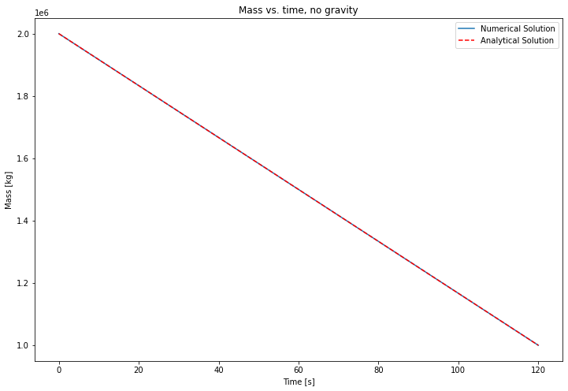

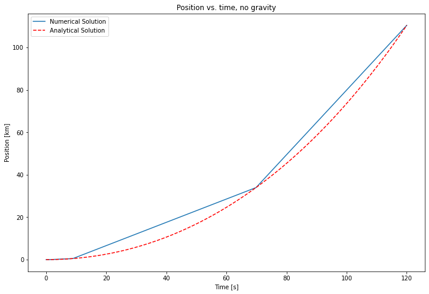

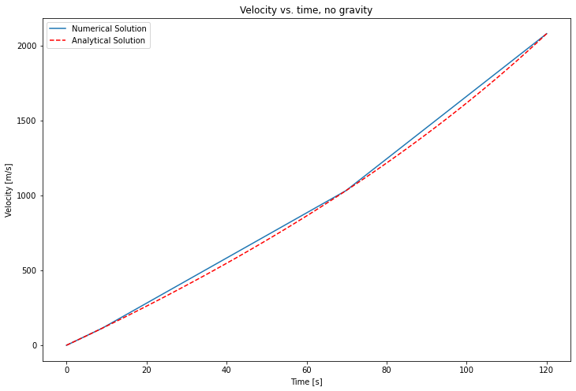

```
The difference between the two solutions is given by
(Analytical Position after 120 s - Numerical Position after 120 s) = -3.31e-02 m
which differ by -3.0e-05 %
```

```python
# < Exercise 7, Computational solution for rocket, plots >

### PLOT the mass vs. time

### PLOT the position vs. time

### PLOT the velocity vs. time

#/ < Exercise 7, Computational solution for rocket, plots,
#    Instructor solution >
# ---------------------------------------------
# Plot the mass vs. time
fig, ax = plt.subplots()
ax.set_title("Mass vs. time, no gravity")
ax.set_xlabel('Time [s]')
ax.set_ylabel('Mass [kg]')
ax.plot(r_soln.t, r_soln.y[0])
ax.plot(time_arr, mass_0 - burn_rate*time_arr, '--r')
ax.legend(["Numerical Solution", "Analytical Solution"])
plt.show()

# Plot the position vs. time
fig, ax = plt.subplots()
ax.set_title("Position vs. time, no gravity")
ax.set_xlabel('Time [s]')
ax.set_ylabel('Position [km]')
ax.plot(r_soln.t, r_soln.y[1]/1e3)
ax.plot(time_arr, pos/1e3, '--r')
ax.legend(["Numerical Solution", "Analytical Solution"])
plt.show()

# Plot the velocity vs. time
fig, ax = plt.subplots()
ax.set_title("Velocity vs. time, no gravity")
ax.set_xlabel('Time [s]')
ax.set_ylabel('Velocity [m/s]')
ax.plot(r_soln.t, r_soln.y[2])
ax.plot(time_arr, vel, '--r')
ax.legend(["Numerical Solution", "Analytical Solution"])
plt.show()

print("The difference between the two solutions is given by")
print("(Analytical Position after 120 s - Numerical Position after 120 s) = "
      + "{0:3.2e} m".format(r_soln.y[1,-1] - pos[-1]))
print("which differ by {:1.1e} %".
      format((r_soln.y[1,-1] - pos[-1])/pos[-1]*100))
# ---------------------------------------------
#/
```

You should have found that the difference in final position for the analytical and computational solutions is less than 0.0001 %! This is a very high level of accuracy.

However, you also probably noticed that the time steps in the computational solution are very coarse, resulting in a choppy looking plot. What happened is that `solve_ivp()` did not need to use small time steps to find an accurate final step. For this exercise, though, we would like to know the solution with much finer time spacing. To request that `solve_ivp()` use no time step spacing greater than 0.1 seconds, set `max_step` in `solve_ivp()` to 0.1.

#### Exercise 8

Copy the code from the previous two exercises to again find and plot the computational solution. This time, though, replace the call to `solve_ivp()` with the following line of code:

```
r_soln = solve_ivp(deriv, t_span, r_init, args = (burn_rate, vel_ex), max_step = 0.1)
```

to define a maximum time step size.

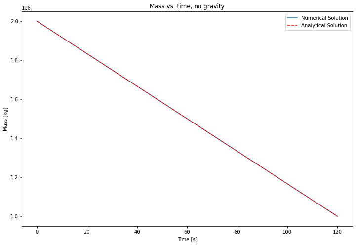

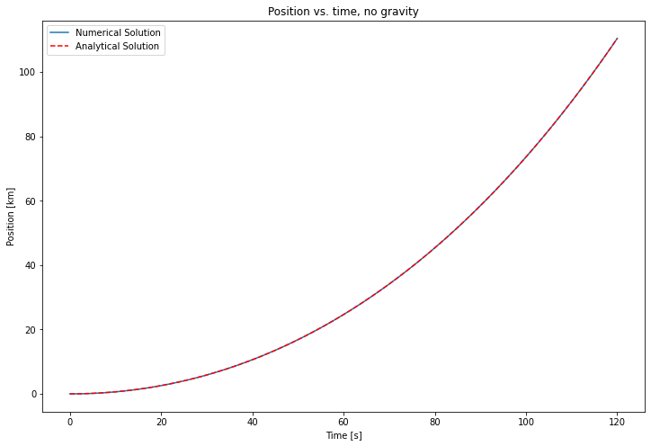

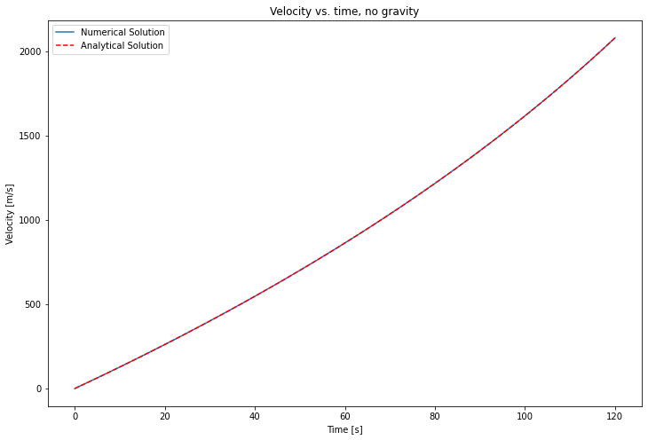

```python
# < Exercise 8, Computational solution with smaller step sizes >

### INCLUDE code to find and plot the solution

#/ < Exercise 8, Computational solution with smaller step sizes,
#    Instructor solution >

r_soln = solve_ivp(deriv, t_span, r_init, args = (burn_rate, vel_ex),
                   max_step = 0.1)

# ---------------------------------------------
# Plot the mass vs. time
fig, ax = plt.subplots()
ax.set_title("Mass vs. time, no gravity")
ax.set_xlabel('Time [s]')
ax.set_ylabel('Mass [kg]')
ax.plot(r_soln.t, r_soln.y[0])
ax.plot(time_arr, mass_0 - burn_rate*time_arr, '--r')
ax.legend(["Numerical Solution", "Analytical Solution"])
plt.show()

# Plot the position vs. time
fig, ax = plt.subplots()
ax.set_title("Position vs. time, no gravity")
ax.set_xlabel('Time [s]')
ax.set_ylabel('Position [km]')
ax.plot(r_soln.t, r_soln.y[1]/1e3)
ax.plot(time_arr, pos/1e3, '--r')
ax.legend(["Numerical Solution", "Analytical Solution"])
plt.show()

# Plot the velocity vs. time
fig, ax = plt.subplots()
ax.set_title("Velocity vs. time, no gravity")
ax.set_xlabel('Time [s]')
ax.set_ylabel('Velocity [m/s]')
ax.plot(r_soln.t, r_soln.y[2])
ax.plot(time_arr, vel, '--r')
ax.legend(["Numerical Solution", "Analytical Solution"])
plt.show()
# ---------------------------------------------
#/
```

### Comparison between `solve_ivp()` and Improved Euler

It is clear that `solve_ivp()` can produce accurate results. However, you have also previously had success using your own Improved Euler integrator. How do these two methods compare in terms of both accuracy and efficiency (how long it takes to run)? While the answer will vary depending on the problem, the following exercise provides a simple comparison for the case of the rocket.

#### Exercise 9*

The following cell contains the template for an Improved Euler integration of the rocket in zero-gravity. It has been modified from your work in Numerical ODE & Projectile Motion and Projectile Motion with Drag to enable the integration of mass, position, and velocity, as well as to include variables for the burn rate and the exhaust speed. Basing your edits on your work in the previous units, add the integration code to the `improved_euler` function adjusted to fit this problem.

*Hint: You do not need to (and should not) define a new derivative function. Simply call `deriv()`, as defined previously in this unit.*

```python
# < Exercise 9, Rocket w/o gravity, Improved Euler Integration function >

def improved_euler(t_arr, r_arr, burn_rate = 0, vel_ex = 0):
    """Integrate a rocket in zero-gravity using the Improved Euler method
    burn_rate is the rate at which the mass is expelled and vel_ex is the
    velocity at which it is expelled."""

    # Create the empty arrays
    mass = np.array([])  # an empty array that will hold the mass solutions
    pos = np.array([])   # positions
    vel = np.array([])   # velocities
    h_step = (t_arr[1] - t_arr[0]) # time step

    ### ADD integration code below

    #/ < Exercise 9, Rocket w/o gravity, Improved Euler Integration function,
    #    Instructor solution >

    # The engine: initialize values, then step through with simple Euler
    #    method (uses a first-order Taylor series)
    for t_step in t_arr:  # this *for* loop sequentially takes on all the
                          #    elements of t_arr, first to last
        mass = np.append(mass, r_arr[0]) # extend the array by tacking the
                                         #    latest mass onto the end of it
                                         #    starting from r_arr which is
                                         #    originally a copy of r_init
        pos = np.append(pos, r_arr[1])
        vel = np.append(vel, r_arr[2])

        # Here is the half-step Euler
        #    evaluate the increment on the half step
        k1 = (h_step/2)*deriv(t_step, r_arr, burn_rate, vel_ex)
        # this is the whole step after sniffing out the derivatives at the
        #    midpoint
        r_arr = r_arr + h_step*deriv(t_step, r_arr + k1, burn_rate, vel_ex)

    #/
    r_soln = np.array([mass, pos, vel])

    return r_soln # return the solution
```

The next three cells import the `timeit` library and then run the `solve_ivp()` and `improved_euler()` integration for a fixed array of times (`time_arr`, previously defined to be used in the analytical calculation). To use a fixed array of times with `solve_ivp()`, set the optional parameter `t_eval` in `solve_ivp()` to the desired array, in this case `time_arr'.

```python
import timeit
```

```python
%%timeit
r_soln_imp_euler = improved_euler(time_arr, r_init, burn_rate, vel_ex)
```

```
1.48 ms ± 123 µs per loop (mean ± std. dev. of 7 runs, 1000 loops each)
```

```python
%%timeit
r_soln_solve_ivp = solve_ivp(deriv, t_span, r_init, t_eval = time_arr,
                             args = (burn_rate, vel_ex))
```

```
1.21 ms ± 86 µs per loop (mean ± std. dev. of 7 runs, 1000 loops each)
```

#### Exercise 10*

Plot the positions versus time for the rocket, as calculated using `solve_ivp()`, your Improved Euler integrator, and analytically. Then calculate the difference between the position of the rocket after 120 seconds for each computational solution and the analytical solution.

*Hint:* Because you will be plotting both the solution from your `improved_euler()` function and `solve_ivp()`, you should make sure to give those solutions different names.

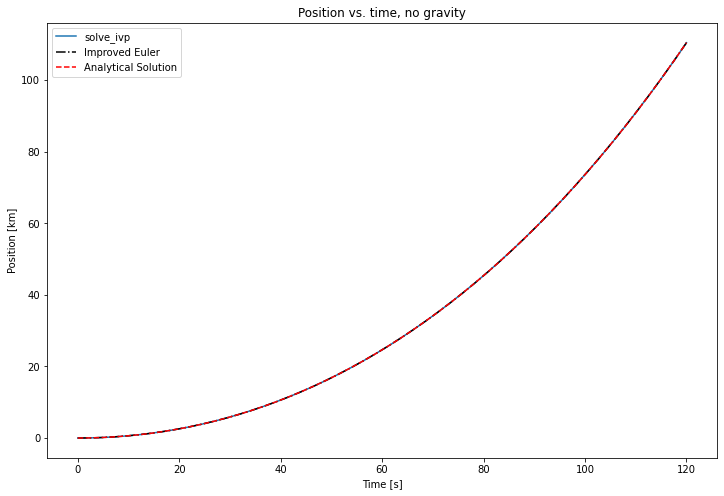

```
Analytical Position after 120 s - solve_ivp Position after 120 s = -3.31e-02 m (-2.99e-05%)
Analytical Position after 120 s - Improved Euler Position after 120 s= -1.39e+01 m (-1.26e-02%)
```

```python
# < Exercise 10, Rocket w/o gravity, Integration method comparison >

# Using Improved Euler to calculate trajectory
r_soln_imp_euler = improved_euler(time_arr, r_init, burn_rate, vel_ex)
# Using solve_ivp to calculate trajectory
r_soln_solve_ivp = solve_ivp(deriv, t_span, r_init, t_eval = time_arr,
                             args = (burn_rate, vel_ex))

### PLOT the position vs. time

#/ < Exercise 10, Rocket w/o gravity, Integration method comparison,
#    Instructor solution >
fig, ax = plt.subplots()
ax.set_title("Position vs. time, no gravity")
ax.set_xlabel('Time [s]')
ax.set_ylabel('Position [km]')
ax.plot(r_soln_solve_ivp.t, r_soln_solve_ivp.y[1]/1e3)
ax.plot(time_arr, r_soln_imp_euler[1]/1e3, '-.k')
ax.plot(time_arr, pos/1e3, '--r')
ax.legend(["solve_ivp", "Improved Euler", "Analytical Solution"])
plt.show()

print("Analytical Position after 120 s - solve_ivp Position after 120 s = "
      + "{0:3.2e} m ({1:3.2e}%)".format(r_soln_solve_ivp.y[1,-1] - pos[-1],
                                        (r_soln_solve_ivp.y[1,-1] - pos[-1])
                                        /pos[-1]*100))
print("Analytical Position after 120 s - Improved Euler Position after 120 s"
      + "= {0:3.2e} m ({1:3.2e}%)".format(r_soln_imp_euler[1,-1] - pos[-1],
                                          (r_soln_imp_euler[1,-1] - pos[-1])
                                          /pos[-1]*100))
#/
```

Comparing the results of `solve_ivp()` and your Improved Euler integration when calculated over the same set of time steps reveals that `solve_ivp()` produces much more accurate results. While Improved Euler was able to produce incredibly accurate results for a projectile subject to constant acceleration, its accuracy decreases as the complexity of the problem increases. By using a higher-order Taylor series approximation as the basis for the integrator, `solve_ivp()`, is able to achieve much higher accuracy.

There are a number of additional advantages to using `solve_ivp()`. For example, the adaptive time stepping means that `solve_ivp()` can appropriately reduce the number of time steps during slowly changing portions of the integration to save time without significantly reducing the accuracy. Additionally, you probably noticed that it was much easier to use `solve_ivp()` than to adapt your Improved Euler integration method to a new problem.

## Motion of a Rocket in a Constant Gravitational Field

For the remainder of this unit, you will model the launch of the Space Shuttle to the International Space Station located in Low Earth Orbit.

Suppose the rocket is taking off vertically from the surface of Earth. Because Earth's gravitational field is roughly constant in Low Earth Orbit, this situation can be approximated as a rocket subject to a constant external force along the same directional line as the velocity. (OK, we acknowledge that you ought to launch it at some angle so as to match the angular momentum required to keep it in a circular orbit, but that is a further refinement. Here we're illustrating why you want to use a *staged* rocket.)

### Analytical solution

#### Exercise 11

On a separate sheet of paper, show that the equation of motion for this circumstance can be written as

\begin{equation} m \dot v = -\dot m v_{ex} - m g \end{equation}

Then rewrite the equation assuming a constant rate of mass ejection such that $\dot m = -k$ and $m = m_0 - k t$. Use separation of variables to solve for $v$ as a function of $t$ by rearranging the equation such that all terms involving $v$ are on the left and all terms involving $t$ are on the right and integrating.

This problem is equivalent to part $b$ of Problem 3.11 from *Classical Mechanics*.

#### Exercise 12*

Now integrate your above equation for $v(t)$ to find that the rocket's height as a function of $t$ is \begin{equation} y(t) = v_{ex} t - \frac{1}{2} g t^2 - \frac{m v_{ex}}{k} \ln \left( \frac{m_0}{m} \right) \end{equation}

You should be able to repeat much of your derivation from **Exercise 4**.

This problem is equivalent to Problem 3.13 from *Classical Mechanics*.

#### Exercise 13*

Use the equations you derived above to find the velocity and position of the rocket released vertically in a uniform gravitational field as a function of time. Continue to assume the same parameters for the rocket's initial mass, rate of mass expulsion, and velocity of mass expulsion. Plot the position and velocity as a function of time for the first 120 seconds of the launch.

*How does the height of the rocket after 120 seconds change when gravity is included?*

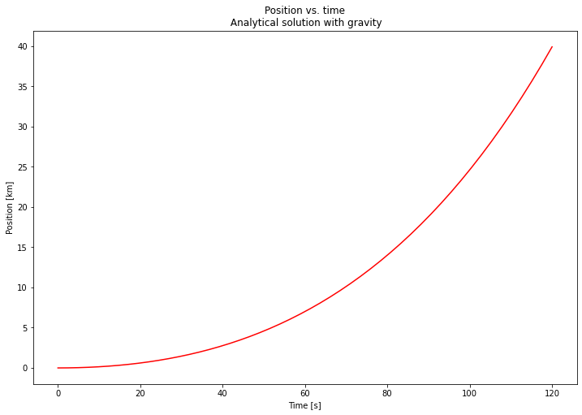

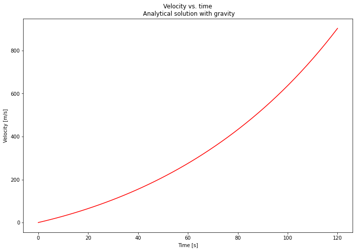

```
The maximum height with gravity is now 39.9 km
```

```python
# < Exercise 13, Analytical solution for rocket >

grav = 9.8 # [m/s^2]; gravitational acceleration near the surface of Earth

### PLOT the position vs. time

### PLOT the velocity vs. time

#/ < Exercise 13, Analytical solution for rocket, Instructor solution >
# ---------------------------------------------

time_arr = (mass_0 - mass)/burn_rate

vel = vel_ex*np.log(mass_0/(mass_0 - burn_rate*time_arr)) - grav*time_arr
pos = (vel_ex*((time_arr - mass_0/burn_rate)
              *np.log(mass_0/(mass_0 - burn_rate*time_arr)) + time_arr)
       - 0.5*grav*time_arr**2)

# Plot the position vs. time
fig, ax = plt.subplots()
ax.set_title("Position vs. time\n Analytical solution with gravity")
ax.set_xlabel('Time [s]')
ax.set_ylabel('Position [km]')
ax.plot(time_arr, pos/1e3, color = 'r')
plt.show()

# Plot the velocity vs. time
fig, ax = plt.subplots()
ax.set_title("Velocity vs. time\n Analytical solution with gravity")
ax.set_xlabel('Time [s]')
ax.set_ylabel('Velocity [m/s]')
ax.plot(time_arr, vel, color = 'r')
plt.show()
print("The maximum height with gravity is now {:.1f} km".format(pos[-1]/1000))
# ---------------------------------------------
#/
```

### Computational solution

#### Exercise 14

Now that you have found the analytical solution, find the computational solution. To do this, you will need to define a new `deriv()` function (I suggest renaming it `deriv_g()`) with the appropriate modification to the calculation of the derivatives. Include plots for the mass, position, and velocity of the rocket as a function of time for the first 120 seconds of the launch. Overplot the analytical solution for the velocity and (provided you completed **Excercises 12** and **13**) the position on top of the computational solution. As in **Exercise 8**, tell `solve_ivp()` to use a maximum time step spacing of 0.1 seconds.

```python
# < Exercise 14, Computational solution for rocket in a gravitational field,
#    derivative function >

### DEFINE a new derivative function that includes the effect of gravity

#/ < Exercise 14, Computational solution for rocket in a gravitational field,
#    derivative function, Instructor solution >
# ---------------------------------------------
# As you did when writing your own integrator, create a function to evaluate
#    the derivatives
def deriv_g(t_now, r_now, burn_rate, vel_ex):
    """ Supplies the derivatives of mass, position, and velocity to be used
    by the differential equation integrator, solve_ivp. The optional
    parameters, burn_rate and vel_ex, are the burn rate and the exhaust
    speed."""

    mass, pos, vel = r_now  # unpack the r-array for the mass, position, and
                            # velocity

    dmass_dt = -burn_rate
    dpos_dt = vel
    dvel_dt = -1*(vel_ex/mass)*dmass_dt - grav

    return np.array([dmass_dt, dpos_dt, dvel_dt])
#/
```

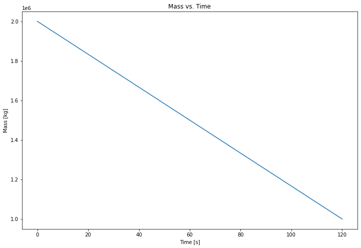

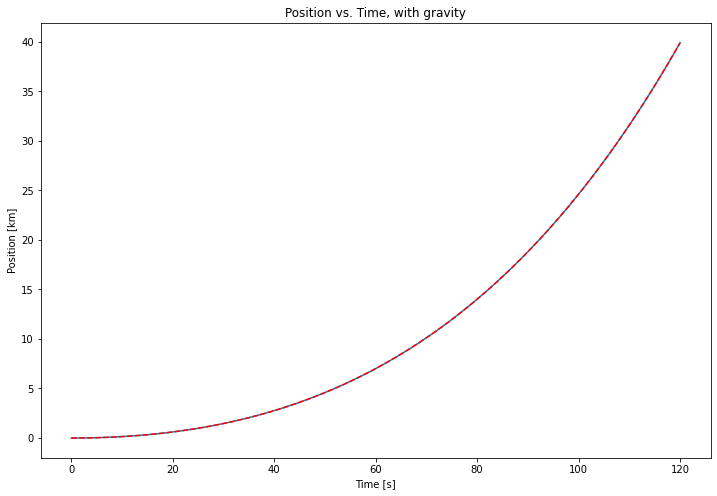

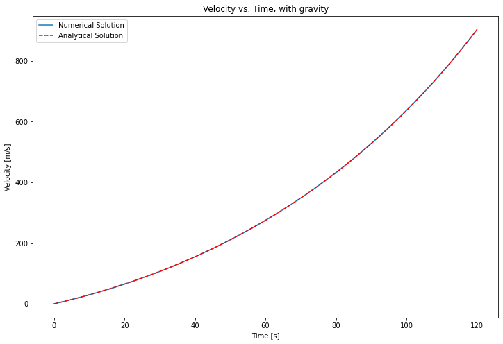

```
The maximum height with gravity (computational solution) is now 39.9 km
```

```python
# < Exercise 14, Computational solution for rocket in a gravitational field >

### CALCULATE the trajectory of the rocket using solve_ivp()

### PLOT mass, position, and velocity versus time

#/ < Exercise 14, Computational solution for rocket in a gravitational field,
#    Instructor solution >
# ---------------------------------------------

t_end = burn_time
delta_t = 0.1
t_arr = np.arange(0.0, t_end, delta_t)
t_span = (0.0, t_end)
# Set the initial conditions
r_init = np.array([mass_0, 0, 0]) # Initial state; mass, position, and velocity

# Call solve_ivp
r_soln = solve_ivp(deriv_g, t_span, r_init, args = (burn_rate, vel_ex),
                   max_step = 0.1)

# Plot the mass vs. time
fig, ax = plt.subplots()
ax.set_title("Mass vs. Time")
ax.set_xlabel('Time [s]')
ax.set_ylabel('Mass [kg]')
ax.plot(r_soln.t, r_soln.y[0])
plt.show()

# Plot the position vs. time
fig, ax = plt.subplots()
ax.set_title("Position vs. Time, with gravity")
ax.set_xlabel('Time [s]')
ax.set_ylabel('Position [km]')
ax.plot(r_soln.t, r_soln.y[1]/1000)
ax.plot(time_arr, pos/1000, '--r')
plt.show()

# Plot the velocity vs. time
fig, ax = plt.subplots()
ax.set_title("Velocity vs. Time, with gravity")
ax.set_xlabel('Time [s]')
ax.set_ylabel('Velocity [m/s]')
ax.plot(r_soln.t, r_soln.y[2])
ax.plot(time_arr, vel, '--r')
ax.legend(["Numerical Solution", "Analytical Solution"])
plt.show()
print("The maximum height with gravity (computational solution) is now "
      + "{:.1f} km".format(r_soln.y[1][-1]/1000))
#/
```

## Launching to the International Space Station

The launch of the Space Shuttle to the International Space Station actually takes place over two stages. During the first stage (what you have modeled thus far) the two solid rocket boosters provide the majority of the thrust. After 120 seconds, the empty tanks are jettisoned (and recovered via parachute), further reducing the rocket's mass. Over the following 6.5 minutes, the main engine continues to burn fuel from the external tank.

#### Exercise 15

Computationally model the two-stage launch of the Space Shuttle using the following approximate parameters. As in **Exercise 8,** tell `solve_ivp()` to use a maximum time step of 0.1 seconds. When setting the initial conditions for the second stage, *use the final conditions from the first stage, but be sure to reduce the mass of the rocket by the mass of the two solid rocket boosters.* For defining the time span of the integration, `t_span`, for the second stage, it is easiest to set the initial time equal to the final time from the first stage. For example

```
t_span = [0.0, 120] # Time span for integration of the first stage
t_span_2 = [120, 120 + 6.5*60] # Time span for integration of the second stage
```

- Stage 1: Let the initial mass of the rocket be $2 \times 10^6$ kg. As in the previous exercises, assume a 120 s burn time and an expulsion of $1 \times 10^6$ kg of fuel.
- Stage 2: After the two solid rocket boosters (each with mass 87500 kg) are emptied, they are jettisoned (separated via explosive bolts). A further $733500$ kg of fuel is then expelled from the external tank across the next 6.5 minutes. This mass is expelled at a considerably higher velocity of $4447$ m/s, because of the higher burning speed of hydrogen/oxygen compared with the solid-fuel boosters.

*For ease of calculation, some approximations have been made. For instance, you will assume a constant burn rate during each of the two stages. In reality, though, the burn rate is initially higher in the second phase than stated and then reduced part way through to prevent the rocket from exceeding 29.4 m/s$^2$ (3 g), which would damage the structure, and needlessly compress the occupants. Additionally, we are modeling a radial launch, when in reality the trajectory of the Space Shuttle curved soon after leaving the launchpad to be roughly tangential to the surface of Earth.*

*Hint:* When plotting the trajectories during the first and second stages, there is no need to combine the arrays. You can simply plot the trajectory from each stage individually, perhaps in different colors.

```python
# < Exercise 15, Two-stage rocket launch in a gravitational field, finding the
#    solution >

### CALCULATE the trajectory across the two stages

#/ < Exercise 15, Two-stage rocket launch in a gravitational field, finding
#    the solution, Instructor solution >
# Stage 1
t_span = [0.0, burn_time] # Time span
# Set the initial conditions
r_init = np.array([mass_0, 0.0, 0.0]) # Initial mass, position, and velocity

# Call solve_ivp
r_soln = solve_ivp(deriv_g, t_span, r_init, args = (burn_rate, vel_ex),
                   max_step = 0.1)
# Extra
accel = (vel_ex/r_soln.y[0])*burn_rate - grav

# Stage 2, parameters
vel_ex_2 = 4447 # [m/s]; exhaust velocity of external tank (hydrogen/oxygen
                #    has a remarkably high flame speed)
burn_time_2 = 6.5*60 # 6.5 minute second stage burn
t_span_2 = [r_soln.t[-1], r_soln.t[-1] + burn_time_2]
mass_propel_2 = 760000 - 26500  # [kg]; Mass of propellant in Super Lightweight
                                # external tank

burn_rate_2 = mass_propel_2/burn_time_2
# Set the ICs from the final conditions of the previous burn stage
r_init = r_soln.y[:,-1]  # Initial state; mass, position, and velocity are
                         #  ending values of Stage 1, except modified mass

r_init[0] = r_init[0] - 2*87500  # jettison two empty solid rocket boosters;
                                 #    each with mass 87500 kg

r_soln_2 = solve_ivp(deriv_g, t_span_2, r_init, args = (burn_rate_2, vel_ex_2),
                     max_step = 0.1)
# Extra
accel_2 = (vel_ex_2/r_soln_2.y[0])*burn_rate_2 - grav

#/
```

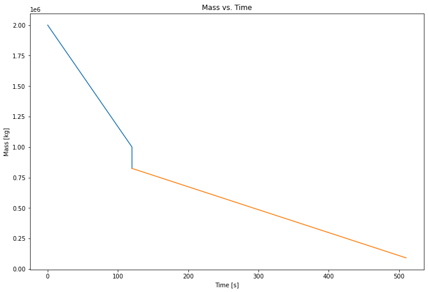

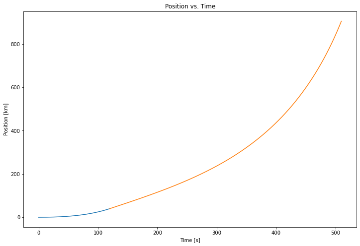

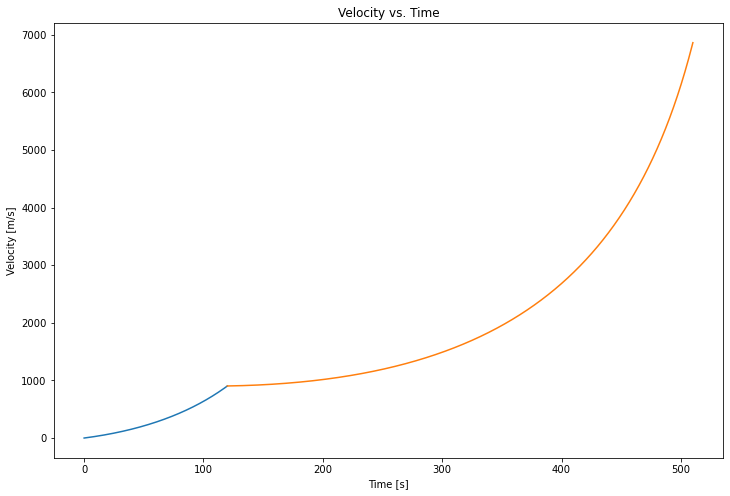

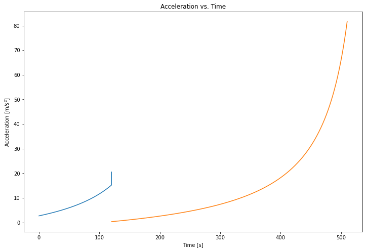

```python
# < Exercise 15, Two-stage rocket launch in a gravitational field, Plots >

### PLOT the mass vs. time

### PLOT the position vs. time

### PLOT the velocity vs. time

#/ < Exercise 15, Two-stage rocket launch in a gravitational field, Plots,
#    Instructor solution >
# Plot the mass vs. time
fig, ax = plt.subplots()
ax.set_title("Mass vs. Time")
ax.set_xlabel('Time [s]')
ax.set_ylabel('Mass [kg]')
ax.plot(r_soln.t, r_soln.y[0])
ax.plot(r_soln_2.t, r_soln_2.y[0])
plt.show()

# Plot the position vs. time
fig, ax = plt.subplots()
ax.set_title("Position vs. Time")
ax.set_xlabel('Time [s]')
ax.set_ylabel('Position [km]')
ax.plot(r_soln.t, r_soln.y[1]/1000)
ax.plot(r_soln_2.t, r_soln_2.y[1]/1000)
plt.show()

# Plot the velocity vs. time
fig, ax = plt.subplots()
ax.set_title("Velocity vs. Time")
ax.set_xlabel('Time [s]')
ax.set_ylabel('Velocity [m/s]')
ax.plot(r_soln.t, r_soln.y[2])
ax.plot(r_soln_2.t, r_soln_2.y[2])
plt.show()

# EXTRA
# Plot the acceleration vs. time
fig, ax = plt.subplots()
ax.set_title("Acceleration vs. Time")
ax.set_xlabel('Time [s]')
ax.set_ylabel(r'Acceleration [m/$s^2$]')
accel = (vel_ex/r_soln.y[0])*burn_rate - grav
ax.plot(r_soln.t, accel)
accel_2 = (vel_ex_2/r_soln_2.y[0])*burn_rate_2 - grav
ax.plot(r_soln_2.t, accel_2)
plt.show()
#/
```

#### Exercise 16*

Verify that the final velocity of the rocket is *similar* to the orbital velocity at the radius of the International Space Station. To do this, you will need to calculate the circular velocity for an object in a gravitational orbit around Earth 140 km above the surface of Earth. You should find that after stage 2 in your model is complete, the Space Shuttle is traveling at about 90% speed of the International Space Station.

*Hint:* Remember that the equation for Newtonian gravity is $$ \vec{F_g} = -G \frac{M m}{d^2}\hat{d} $$ where *G* is the gravitational constant, *M* and *m* are the masses of the two objects, and *$\hat{d}$* is the vector between the two centers of the masses.

*Hint:* You will find the final velocity you calculate to be somewhat lower than that of the International Space Station. This is because of the approximations alluded to in **Exercise 15** and because we are neglecting the additional velocity boost the rocket receives from the rotational motion of Earth as the rocket enters a near-equatorial orbit. A somewhat higher-energy launch is used for spy satellites, which tend to be launched into *polar orbits*. It's considered *bad form* to launch into a *retrograde orbit* (east-to-west) because potential head-on collisions are spectacularly un-neighborly.

```python
# < Exercise 16, Calculating the orbital velocity of the ISS >

### INCLUDE your calculation here

#/ < Exercise 16, Calculating the orbital velocity of the ISS,
#    Instructor solution >
mass_earth = 6e24 # [kg]; Mass of Earth
grav_const = 6.6743e-11 # [m^3 kg^-1 s^-2]; Gravitational constant

radius_earth = 6378*1000 # [m]; Radius of Earth
radius_orbit = radius_earth + 140*1000 # [m]; Orbital radius of ISS

vel_circ = np.sqrt(grav_const*mass_earth/radius_orbit**2*radius_orbit)
print("Orbital velocity of ISS: {:3.2f} m/s".format(vel_circ))
print("Velocity of Space Shuttle after Stage 2: {:3.2f} m/s".
      format(r_soln_2.y[2, -1]))
#/
```

```
Orbital velocity of ISS: 7838.29 m/s
Velocity of Space Shuttle after Stage 2: 6860.59 m/s
```

#### Exercise 17*

Would the Space Shuttle have been able to reach the orbital velocity of the International Space Station if the two solid rocket booster tanks had not been jettisoned before phase two of the burn? Repeat your calculations from **Exercise 15** with this adjustment to find the effect of jettisoning the solid rocket booster tanks.

```
Final velocity if tanks are not jettisoned: 4138.07 m/s
which is insufficient to match the orbital speed of the Space Station.
```

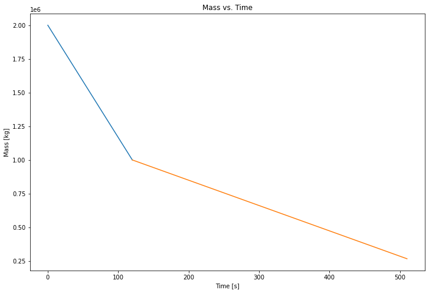

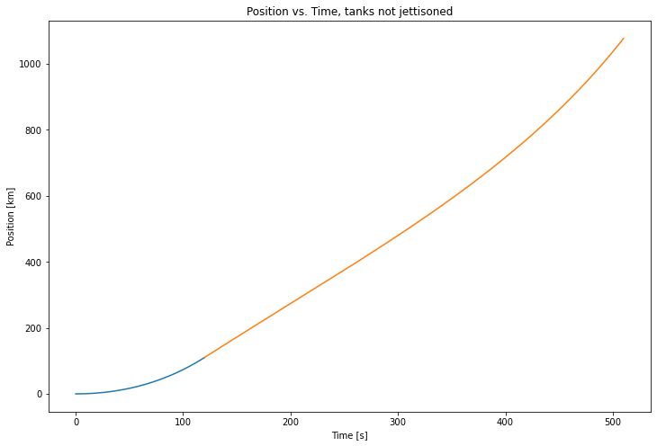

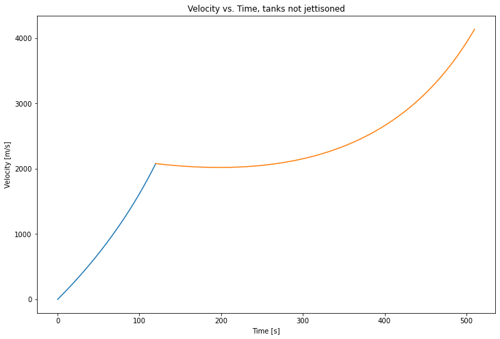

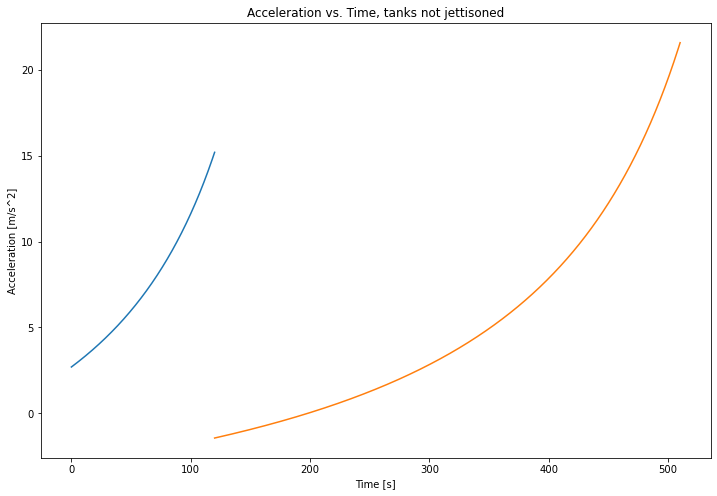

```python
# < Exercise 17, Two-stage rocket launch in a gravitational field, without
#    jettisoning first stage >

### CALCULATE the trajectory across the two stages

#/ < Exercise 17, Two-stage rocket launch in a gravitational field, without
#    jettisoning first stage, Instructor solution >
# Stage 1
t_span = [0.0, burn_time] # Time span
# Set the initial conditions
r_init = np.array([mass_0, 0, 0]) # Initial state; mass, position, and velocity

# Call solve_ivp
r_soln = solve_ivp(deriv, t_span, r_init, args = (burn_rate, vel_ex),
                   max_step = 0.1)

# Stage 2, parameters
vel_ex_2 = 4447 # [m/s]; Expulsion from external tank
t_end_2 = 6.5*60 #
t_span_2 = [r_soln.t[-1], r_soln.t[-1] + burn_time_2]
mass_propel_2 = 760000 - 26500  # [kg]; Mass of propellant in Super Lightweight
                                # external tank
burn_rate_2 = mass_propel_2/(burn_time_2)

# Set the ICs from the final conditions of the previous burn stage
r_init = r_soln.y[:,-1] # Initial state; mass, position, and velocity
r_init[0] = r_init[0] # Now no longer jettison the tanks

r_soln_2 = solve_ivp(deriv_g, t_span_2, r_init, args = (burn_rate_2, vel_ex_2),
                     max_step = 0.1)

print("Final velocity if tanks are not jettisoned: {:3.2f} m/s".
      format(r_soln_2.y[2, -1]))
print("which is insufficient to match the orbital speed of the Space Station.")
# Plot the mass vs. time
fig, ax = plt.subplots()
ax.set_title("Mass vs. Time")
ax.set_xlabel('Time [s]')
ax.set_ylabel('Mass [kg]')
ax.plot(r_soln.t, r_soln.y[0])
ax.plot(r_soln_2.t, r_soln_2.y[0])
plt.show()

# Plot the position vs. time
fig, ax = plt.subplots()
ax.set_title("Position vs. Time, tanks not jettisoned")
ax.set_xlabel('Time [s]')
ax.set_ylabel('Position [km]')
ax.plot(r_soln.t, r_soln.y[1]/1000)
ax.plot(r_soln_2.t, r_soln_2.y[1]/1000)
plt.show()

# Plot the velocity vs. time
fig, ax = plt.subplots()
ax.set_title("Velocity vs. Time, tanks not jettisoned")
ax.set_xlabel('Time [s]')
ax.set_ylabel('Velocity [m/s]')
ax.plot(r_soln.t, r_soln.y[2])
ax.plot(r_soln_2.t, r_soln_2.y[2])
plt.show()

# EXTRA
# Plot the acceleration vs. time
fig, ax = plt.subplots()
ax.set_title("Acceleration vs. Time, tanks not jettisoned")
ax.set_xlabel('Time [s]')
ax.set_ylabel('Acceleration [m/s^2]')
accel = (vel_ex/r_soln.y[0])*burn_rate - grav
ax.plot(r_soln.t, accel)
accel_2 = (vel_ex_2/r_soln_2.y[0])*burn_rate_2 - grav
ax.plot(r_soln_2.t, accel_2)
plt.show()
#/
```

## Check-out

#### Exercise 18

Briefly summarize the ideas in this unit.

## Challenge Problem

Most of the flight of the Space Shuttle is at very high elevations where air resistance is negligible. To see the effect of air resistance, instead model the flight of a 0.2 m diameter water rocket. Create a new derivative function that includes the effect of quadratic drag and assume that $\gamma = 0.25$ N $\text{s}^2$/$\text{m}^4$.

Let the initial mass of the water rocket be 0.7 kg and the final mass be 0.1 kg. Assume that all the fuel is expelled over 0.1 s at a constant exhaust speed of 20 m/s. Note that the latter approximation is a particularly poor one — in real life, the launch of a water rocket proceeds over two stages, one during which water is expelled and one during which the pressurized gas is expelled, and the speed of expulsion depends on the changing pressure inside the bottle. For more context, see: C. J. Gommes, "A more thorough analysis of water rockets: Moist adiabats, transient flows, and inertial forces in a soda bottle," $\it{Am. J. Phys.}$, **78**, 236–243 (2010): . https://doi.org/10.1119/1.3257702

Computationally determine the flight of a vertically launched water rocket subject to air resistance and gravity during the first 0.1 seconds and compare it to the analytical solution for the flight without air resistance.

You may also wish to extend the trajectory to see what happens after the fuel is expended. One way to do this is to numerically calculate the trajectory for the time span between 0.1 and 3.5 seconds, using the final state of the rocket from the earlier stage as your new initial conditions and letting `burn_rate = 0` and `vel_ex = 0`.

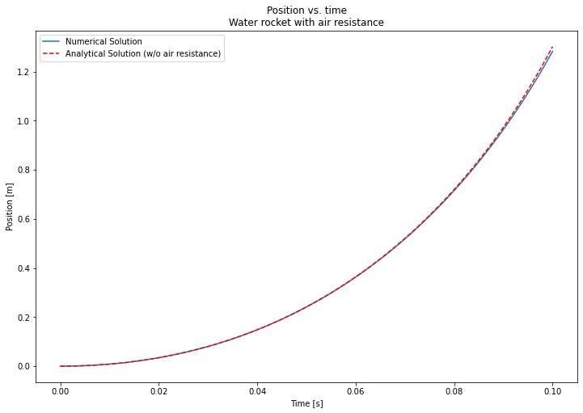

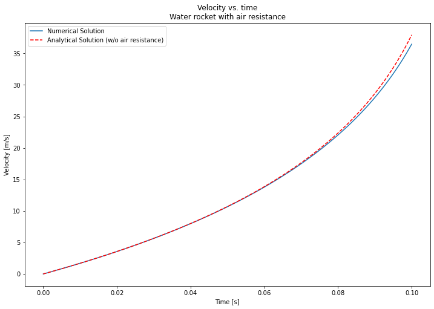

```python
#/ < Exercise 19, Computational solution for water rocket, Instructor solution >
# ---------------------------------------------

# suppress "divide by zero" error message
np.seterr(divide='ignore')

# Defining parameters of the system
mass_0 = 0.7 # [kg]; initial mass
mass_final = 0.1 # [kg]; final mass
burn_time = 0.1 # [s]; time over which mass is expelled
burn_rate = (mass_0 - mass_final)/burn_time  # [kg/s]; rate at which mass is
                                             # expelled

vel_ex = 20 # [m/s]; velocity at which mass is expelled

gamma = 0.25 # [N*s^2/m^4]; term for quadratic air resistance
diameter = 0.2 # [m]; Diameter of rocket

# As you did when writing your own integrator, create a function to evaluate
#    the derivatives
def deriv_g_airresist(t_now, r_now, burn_rate = 0, vel_ex = 0, c_drag = 0):
    """ Supplies the derivatives of mass, position, and velocity to be used
    by the differential equation integrator, solve_ivp. The optional
    parameters burn_rate, vel_ex, and c_drag, are the burn rate, the exhaust
    speed, and the coefficient of quadratic air resistance, respectively."""

    mass, pos, vel = r_now  # unpack the r-array

    dmass_dt = -burn_rate
    dpos_dt = vel
    if vel != 0:
        dvel_dt = (-1*vel_ex/mass*dmass_dt - grav
                   - c_drag*vel**2/mass*(vel/np.abs(vel)))
    else:
        dvel_dt = -1*vel_ex/mass*dmass_dt - grav
    return np.array([dmass_dt, dpos_dt, dvel_dt])

t_end = burn_time
t_span = [0, t_end]

# Set the initial conditions
r_init = np.array([mass_0, 0, 0])  # Initial state; mass, position, and velocity

r_soln = solve_ivp(deriv_g_airresist, t_span, r_init, max_step = 0.001,
                   args = (burn_rate, vel_ex, gamma*diameter**2))

# Coasting Stage; EXTRA
#    During this stage, the rocket starts coasting and is accelerated only by
#    gravity.
t_end_1 = 3.5 # [s]
t_span_1 = [r_soln.t[-1], t_end_1]

# Set the ICs from the final conditions of the previous burnstage
r_init = r_soln.y[:, -1] # Initial state; mass, position, and velocity
r_soln_1 = solve_ivp(deriv_g_airresist, t_span_1, r_init, max_step = 0.001,
                     args = (0, 0, gamma*diameter**2))

# Analytical solution without air resistance
vel = vel_ex*np.log(mass_0/(mass_0 - burn_rate*r_soln.t)) - grav*r_soln.t
pos = (vel_ex*((r_soln.t - mass_0/burn_rate)
              *np.log(mass_0/(mass_0- burn_rate*r_soln.t)) + r_soln.t)
       - 0.5*grav*r_soln.t**2)
accel = (-1*vel_ex/r_soln.y[:,0]*burn_rate - grav
         - gamma*diameter**2*r_soln.y[:,2]**2
         /r_soln.y[:,0]*(r_soln.y[:,2]/np.abs(r_soln.y[:,2])))
# Coasting stage; EXTRA
vel_1 = -grav*(r_soln_1.t - r_soln_1.t[0]) + vel[-1]
pos_1 = (-0.5*grav*(r_soln_1.t - r_soln_1.t[0])**2
         + vel[-1]*(r_soln_1.t - r_soln_1.t[0]) + pos[-1])

# Plot the position vs. time
fig, ax = plt.subplots()
ax.set_title("Position vs. time\nWater rocket with air resistance")
ax.set_xlabel('Time [s]')
ax.set_ylabel('Position [m]')
ax.plot(r_soln.t, r_soln.y[1])
ax.plot(r_soln.t, pos, '--r')  # plot analytical position w/o air resistance
ax.legend(["Numerical Solution", "Analytical Solution (w/o air resistance)"])
plt.show()

# Plot the velocity vs. time
fig, ax = plt.subplots()
ax.set_title("Velocity vs. time\nWater rocket with air resistance")
ax.set_xlabel('Time [s]')
ax.set_ylabel('Velocity [m/s]')
ax.plot(r_soln.t, r_soln.y[2])
ax.plot(r_soln.t, vel, '--r')  # plot analytical velocity w/o air resistance
ax.legend(["Numerical Solution", "Analytical Solution (w/o air resistance)"])
plt.show()
#/
```